# City level report

Orestis

17/07/2020

# Data description

How many observations do we gain or lose?

First, notice that we lose some countries from Movement alone, as not every country has city-level info. Specifically:

```
##  [1] "Afghanistan"          "Aruba"                "Bahrain"
##  [4] "Bangladesh"           "Belarus"              "Bosnia & Herzegovina"
##  [7] "Botswana"             "Costa Rica"           "Fiji"
## [10] "Georgia"              "Ghana"                "Guinea-Bissau"
## [13] "Hong Kong SAR China"  "Iraq"                 "Kazakhstan"
## [16] "Laos"                 "Liechtenstein"        "Luxembourg"
## [19] "Macedonia"            "Mali"                 "Malta"
## [22] "Moldova"              "Morocco"              "Myanmar (Burma)"
## [25] "Nepal"                "Panama"               "Papua New Guinea"
## [28] "Qatar"                "Russia"               "Serbia"
## [31] "Singapore"            "South Korea"          "Sri Lanka"
## [34] "Taiwan"               "Tajikistan"           "Thailand"
## [37] "Trinidad & Tobago"    "Ukraine"              "Venezuela"
## [40] "Yemen"                "Zambia"
```

Of those 41 countries, South Korea is the only really big pitty… But, so far, this is not as bad. First, some of these countries we lose anyway from merging Google with GPS. Second, we can always go back and include those missing countries.

|  | Country | City | Temp_C | risktaking | patience | Movement | population | n |
| --- | --- | --- | --- | --- | --- | --- | --- | --- |
| 1 | Argentina | Buenos Aires | 17.9326845093268 | 0.155798207405599 | -0.224845221422222 | -49.4671532846715 |  | 137 |
| 2 | Argentina | Chaco Province | 21.1853203568532 | -0.127871348739024 | -0.173511377756435 | -46.4671532846715 | 496551 | 274 |
| 3 | Argentina | Chubut Province | 13.860300081103 | 0.1310223683 | 0.0227273517 | -48.7912408759124 |  | 137 |
| 4 | Argentina | Cordoba | 9.24074074074074 | 0.319126286781074 | 0.0412319902276423 | -49.5 |  | 6 |
| 5 | Argentina | Entre Rios | 18.2925790754258 | -0.539109331103678 | -0.29163218536371 | -44.2014598540146 | 1970617 | 274 |
| 6 | Argentina | Mendoza Province | 16.919099756691 | -0.331249877997317 | -0.640124916869857 | -38.1167883211679 | 909429 | 274 |
| 7 | Argentina | Rio Negro | 15.7155312246553 | -0.497069734548387 | -0.215400152645161 | -55.9094890510949 |  | 137 |
| 8 | Argentina | Salta Province | 17.2212084347121 | -0.33362065375 | -0.607291957208333 | -35.3021897810219 |  | 137 |
| 9 | Argentina | San Luis Province | 18.7911597729116 | -0.356117746176471 | -0.769586987588235 | -47.6452554744526 |  | 137 |
| 10 | Argentina | Tucuman | 19.4002433090024 | -0.44851427703125 | -0.550880609875 | -38.770802919708 | 828402 | 137 |

[output cut: 436 more lines]

For the final analysis, we probably want to focus on cities that have at least 100 observations for daily temperature.

This leaves us with 419 cities. Peculiarly, according to another metric, we have 424. Let’s look more closely again:

|  | Country | City | Temp_C | risktaking | patience | Movement | population | n |
| --- | --- | --- | --- | --- | --- | --- | --- | --- |
| 1 | Argentina | Buenos Aires |  |  |  | -50.455033557047 |  | 149 |
| 2 | Argentina | Chaco Province |  |  |  | -47.0469798657718 |  | 149 |
| 3 | Argentina | Chubut Province |  |  |  | -49.0630872483221 |  | 149 |
| 4 | Argentina | Entre Rios |  |  |  | -44.5194630872483 |  | 149 |
| 5 | Argentina | Mendoza Province |  |  |  | -38.0456375838926 |  | 149 |
| 6 | Argentina | Rio Negro |  |  |  | -56.4389261744966 |  | 149 |
| 7 | Argentina | Salta Province |  |  |  | -35.0362416107383 |  | 149 |
| 8 | Argentina | San Luis Province |  |  |  | -47.6832214765101 |  | 149 |
| 9 | Argentina | Tucuman |  |  |  | -38.2818791946309 |  | 149 |
| 10 | Australia | Australian Capital Territory |  |  |  | -11.3127516778523 |  | 149 |

[output cut: 414 more lines]

It is a bit weird that although we lose only approx. 30 out of 450 cities, the total amount of observations goes down to 60 thousands from 260 thousands…

The names of the cities derive from Google reports. There are 2 more variables named: “City_GPS” that takes the names from GPS cities and “city” that takes the name from the data set I used for the population variable.

Some countries have more cities than others:

|  | Country | n_cities |
| --- | --- | --- |
| 1 | Argentina | 9 |
| 2 | Australia | 8 |
| 3 | Austria | 6 |
| 4 | Bolivia | 4 |
| 5 | Brazil | 24 |
| 6 | Cambodia | 2 |
| 7 | Cameroon | 4 |
| 8 | Canada | 4 |
| 9 | Chile | 3 |
| 10 | Colombia | 9 |

[output cut: 44 more lines]

On the map:

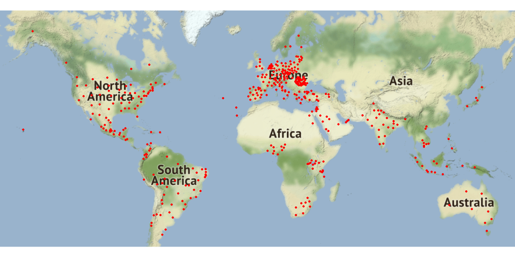

## Random checks

I will now check (pseudo-)random cities and dates with online info, to see if our weather data is sensible.

- Athens, 20/03/2020
  - Our data set says: 11.0277778
  - Internet says: 20C during the day and 7C during the night. Source:https://www.accuweather.com/en/gr/athens/182536/march-weather/182536 Sounds about right…
  - Let’s check for the 16th of March, which according to AccuWeather was really cold: 11C during the day and 8C during the night:
  - 8.75 great
- Munich, 10/05/2020
  - Our data set says: 16.4722222
  - Accuweather: 25/15
  - Let’s check on the 17th of May, where it was really hot: 35/21
  - 12.5277778: this is bad…
  - checking if there was a mistake in the aggregation by looking at the raw data. The closest station I could find is OBERPFAFFENHOFEN, GM and MUNCHEN< GM which report avg temperatures of 54F which is 12.2. So, our matching seems to have worked, but Accuweather seems to disagree with NATIONAL CENTERS FOR ENVIRONMENTAL INFORMATION…
  - Let me check a different site:
    - https://weather.com/weather/monthly/l/e0c0cd4ab9873fee5066145204f7161a0c1f7468722e633345583634cff0bbd6 Here, we see that on the 17th the weather was 21/6, so very similar to our measures and completely in disagreement with accuweather. GOOD.
    - What about on the 10th of May: 22/14. Better. Accuweather cannot get weather accurately in the past. Wouldn’t trust it for the future.
- Florida April, 05
  - our data: 20.7777778
  - weather channel: 22/17 and raining
  - 0
  - Doesn’t show rain.. 0
- Let’s find a city where it rained on a certain day and that was an exception.
  - 28th Feb. in London. It rained with 0.78 cm prcp. Temperature was 11/1.
  - 6.7222222 :Very good.
  - 0 : no rain…
  - 0.23 : 0.23 inches is 0.55 cm
  - Not a big discrepency.

Take-home messages from this exercise: * Our weather matching seems to be working alright. * Do not trust Accuweather * Turn PRCP from inches to cm

# Movement and weather

Does movement correlate with temperature?

```
##
##  Pearson's product-moment correlation
##
## data:  gwmp$Movement and gwmp$Temp_C
## t = -20.138, df = 60885, p-value < 0.00000000000000022
## alternative hypothesis: true correlation is not equal to 0
## 95 percent confidence interval:
##  -0.08922758 -0.07344659
## sample estimates:
##         cor
## -0.08134218
```

```
##
##  Pearson's product-moment correlation
##
## data:  gwmp$Movement and gwmp$Rain
## t = 2.0169, df = 29694, p-value = 0.04371
## alternative hypothesis: true correlation is not equal to 0
## 95 percent confidence interval:
##  0.0003302095 0.0230745230
## sample estimates:
##        cor
## 0.01170388
```

Higher temperatures are associated with lower movement and rainy days with higher movement. Bananas! Let’s calculate a correlation coefficient for every country.